# Crude Death Rates

Stephen Sani

Load required packages

```r
library(readr)
library(vroom)
library(tidyverse)
library(tidyr)
library(ggplot2)
```

# Getting data

Read mortality and population data

```r
# Read mortality data
mortdata <- vroom::vroom("data/mortdata.csv")
# Read population data
popdata <- vroom::vroom("data/popdata.csv")
```

Preview mortality data

```r
head(mortdata, 5)
```

| country | cause | sex | total | d1 | d2 | d3 | d4 | d5 | d6 | d7 | d8 | d9 | d10 | d11 | d12 | d13 | d14 | d15 | d16 | d17 | d18 | d19 |
| --- | --- | --- | --- | --- | --- | --- | --- | --- | --- | --- | --- | --- | --- | --- | --- | --- | --- | --- | --- | --- | --- | --- |
| 4010 | A020 | 2 | 1 | 0 | 0 | 0 | 0 | 0 | 0 | 0 | NA | 0 | 0 | 0 | 0 | 0 | 0 | 0 | 1 | 0 | 0 | 0 |
| 4010 | A029 | 2 | 1 | 0 | 0 | 0 | 0 | 0 | 0 | 0 | NA | 0 | 0 | 0 | 0 | 0 | 0 | 0 | 0 | 1 | 0 | 0 |
| 4010 | A042 | 1 | 1 | 0 | 0 | 0 | 0 | 0 | 0 | 1 | NA | 0 | 0 | 0 | 0 | 0 | 0 | 0 | 0 | 0 | 0 | 0 |
| 4010 | A043 | 2 | 1 | 0 | 0 | 0 | 0 | 0 | 0 | 0 | NA | 0 | 0 | 0 | 0 | 0 | 0 | 1 | 0 | 0 | 0 | 0 |
| 4010 | A044 | 2 | 1 | 0 | 0 | 0 | 0 | 0 | 0 | 0 | NA | 0 | 0 | 0 | 0 | 0 | 0 | 0 | 0 | 0 | 1 | 0 |

Preview population data

```r
head(popdata, 5)
```

| country | name | sex | pop |
| --- | --- | --- | --- |
| 4010 | Austria | 1 | 4062391 |
| 4010 | Austria | 2 | 4274909 |
| 4038 | Croatia | 1 | 2130123 |
| 4038 | Croatia | 2 | 2292387 |
| 4045 | Czech Republic | 1 | 5055890 |

Preview provides some information along with the first five rows. View technical information to get more relevant information on the data.

Technical information on mortality data

```r
glimpse(mortdata)
```

```
## Rows: 29,593
## Columns: 23
## $ country <dbl> 4010, 4010, 4010, 4010, 4010, 4010, 4010, 4010, 4010, 4010, 40…
## $ cause   <chr> "A020", "A029", "A042", "A043", "A044", "A047", "A048", "A052"…
## $ sex     <dbl> 2, 2, 1, 2, 2, 2, 2, 1, 2, 1, 2, 1, 2, 1, 1, 2, 1, 2, 1, 2, 2,…
## $ total   <dbl> 1, 1, 1, 1, 1, 2, 2, 1, 1, 4, 9, 3, 1, 1, 2, 1, 2, 2, 11, 5, 1…
## $ d1      <dbl> 0, 0, 0, 0, 0, 0, 0, 0, 0, 0, 0, 0, 0, 0, 0, 0, 0, 0, 0, 0, 0,…
## $ d2      <dbl> 0, 0, 0, 0, 0, 0, 0, 0, 0, 0, 0, 0, 0, 0, 0, 0, 0, 0, 0, 0, 0,…
## $ d3      <dbl> 0, 0, 0, 0, 0, 0, 0, 0, 0, 1, 0, 0, 0, 0, 0, 0, 0, 0, 0, 0, 0,…
## $ d4      <dbl> 0, 0, 0, 0, 0, 0, 0, 0, 1, 0, 0, 0, 0, 0, 0, 0, 0, 0, 0, 0, 0,…
## $ d5      <dbl> 0, 0, 0, 0, 0, 0, 0, 0, 0, 0, 0, 0, 0, 0, 0, 0, 0, 0, 0, 0, 0,…
## $ d6      <dbl> 0, 0, 0, 0, 0, 0, 0, 0, 0, 0, 0, 0, 0, 0, 0, 0, 0, 0, 1, 0, 0,…
## $ d7      <dbl> 0, 0, 1, 0, 0, 0, 0, 0, 0, 1, 0, 0, 0, 0, 0, 0, 0, 0, 0, 0, 0,…
## $ d8      <lgl> NA, NA, NA, NA, NA, NA, NA, NA, NA, NA, NA, NA, NA, NA, NA, NA…
## $ d9      <dbl> 0, 0, 0, 0, 0, 0, 0, 0, 0, 0, 0, 1, 0, 0, 0, 0, 0, 0, 0, 0, 0,…
## $ d10     <dbl> 0, 0, 0, 0, 0, 0, 0, 0, 0, 0, 0, 0, 0, 0, 1, 0, 1, 0, 0, 0, 0,…
## $ d11     <dbl> 0, 0, 0, 0, 0, 0, 0, 0, 0, 0, 0, 1, 0, 0, 0, 0, 1, 0, 2, 0, 0,…
## $ d12     <dbl> 0, 0, 0, 0, 0, 0, 0, 1, 0, 2, 0, 0, 0, 0, 0, 0, 0, 0, 1, 1, 0,…
## $ d13     <dbl> 0, 0, 0, 0, 0, 0, 0, 0, 0, 0, 1, 0, 0, 0, 0, 0, 0, 0, 1, 0, 0,…
## $ d14     <dbl> 0, 0, 0, 0, 0, 0, 0, 0, 0, 0, 2, 0, 1, 0, 0, 0, 0, 1, 4, 2, 0,…
## $ d15     <dbl> 0, 0, 0, 1, 0, 2, 0, 0, 0, 0, 3, 1, 0, 0, 1, 0, 0, 1, 2, 1, 0,…
## $ d16     <dbl> 1, 0, 0, 0, 0, 0, 1, 0, 0, 0, 2, 0, 0, 0, 0, 0, 0, 0, 0, 0, 0,…
## $ d17     <dbl> 0, 1, 0, 0, 0, 0, 1, 0, 0, 0, 1, 0, 0, 0, 0, 1, 0, 0, 0, 1, 1,…
## $ d18     <dbl> 0, 0, 0, 0, 1, 0, 0, 0, 0, 0, 0, 0, 0, 0, 0, 0, 0, 0, 0, 0, 0,…
## $ d19     <dbl> 0, 0, 0, 0, 0, 0, 0, 0, 0, 0, 0, 0, 0, 0, 0, 0, 0, 0, 0, 0, 0,…
```

From the information on mortality data, d8 have “NA” values. In addition, the data type for d8 is now logical and not double like the other d# columns.

Similar information is provided from the structure of the data

```r
str(mortdata)
```

```
## spc_tbl_ [29,593 × 23] (S3: spec_tbl_df/tbl_df/tbl/data.frame)
##  $ country: num [1:29593] 4010 4010 4010 4010 4010 4010 4010 4010 4010 4010 ...
##  $ cause  : chr [1:29593] "A020" "A029" "A042" "A043" ...
##  $ sex    : num [1:29593] 2 2 1 2 2 2 2 1 2 1 ...
##  $ total  : num [1:29593] 1 1 1 1 1 2 2 1 1 4 ...
##  $ d1     : num [1:29593] 0 0 0 0 0 0 0 0 0 0 ...
##  $ d2     : num [1:29593] 0 0 0 0 0 0 0 0 0 0 ...
##  $ d3     : num [1:29593] 0 0 0 0 0 0 0 0 0 1 ...
##  $ d4     : num [1:29593] 0 0 0 0 0 0 0 0 1 0 ...
##  $ d5     : num [1:29593] 0 0 0 0 0 0 0 0 0 0 ...
##  $ d6     : num [1:29593] 0 0 0 0 0 0 0 0 0 0 ...
##  $ d7     : num [1:29593] 0 0 1 0 0 0 0 0 0 1 ...
##  $ d8     : logi [1:29593] NA NA NA NA NA NA ...
##  $ d9     : num [1:29593] 0 0 0 0 0 0 0 0 0 0 ...
##  $ d10    : num [1:29593] 0 0 0 0 0 0 0 0 0 0 ...
##  $ d11    : num [1:29593] 0 0 0 0 0 0 0 0 0 0 ...
##  $ d12    : num [1:29593] 0 0 0 0 0 0 0 1 0 2 ...
##  $ d13    : num [1:29593] 0 0 0 0 0 0 0 0 0 0 ...
##  $ d14    : num [1:29593] 0 0 0 0 0 0 0 0 0 0 ...
##  $ d15    : num [1:29593] 0 0 0 1 0 2 0 0 0 0 ...
##  $ d16    : num [1:29593] 1 0 0 0 0 0 1 0 0 0 ...
##  $ d17    : num [1:29593] 0 1 0 0 0 0 1 0 0 0 ...
##  $ d18    : num [1:29593] 0 0 0 0 1 0 0 0 0 0 ...
##  $ d19    : num [1:29593] 0 0 0 0 0 0 0 0 0 0 ...
##  - attr(*, "spec")=
##   .. cols(
##   ..   country = col_double(),
##   ..   cause = col_character(),
##   ..   sex = col_double(),
##   ..   total = col_double(),
##   ..   d1 = col_double(),
##   ..   d2 = col_double(),
##   ..   d3 = col_double(),
##   ..   d4 = col_double(),
##   ..   d5 = col_double(),
##   ..   d6 = col_double(),
##   ..   d7 = col_double(),
##   ..   d8 = col_logical(),
##   ..   d9 = col_double(),
##   ..   d10 = col_double(),
##   ..   d11 = col_double(),
##   ..   d12 = col_double(),
##   ..   d13 = col_double(),
##   ..   d14 = col_double(),
##   ..   d15 = col_double(),
##   ..   d16 = col_double(),
##   ..   d17 = col_double(),
##   ..   d18 = col_double(),
##   ..   d19 = col_double()
##   .. )
##  - attr(*, "problems")=<externalptr>
```

Technical information on population data

```r
glimpse(popdata)
```

```
## Rows: 24
## Columns: 4
## $ country <dbl> 4010, 4010, 4038, 4038, 4045, 4045, 4070, 4070, 4080, 4080, 40…
## $ name    <chr> "Austria", "Austria", "Croatia", "Croatia", "Czech Republic", …
## $ sex     <dbl> 1, 2, 1, 2, 1, 2, 1, 2, 1, 2, 1, 2, 1, 2, 1, 2, 1, 2, 1, 2, 1,…
## $ pop     <dbl> 4062391, 4274909, 2130123, 2292387, 5055890, 5263424, 2599139,…
```

View the structure of population data

```r
str(popdata)
```

```
## spc_tbl_ [24 × 4] (S3: spec_tbl_df/tbl_df/tbl/data.frame)
##  $ country: num [1:24] 4010 4010 4038 4038 4045 ...
##  $ name   : chr [1:24] "Austria" "Austria" "Croatia" "Croatia" ...
##  $ sex    : num [1:24] 1 2 1 2 1 2 1 2 1 2 ...
##  $ pop    : num [1:24] 4062391 4274909 2130123 2292387 5055890 ...
##  - attr(*, "spec")=
##   .. cols(
##   ..   country = col_double(),
##   ..   name = col_character(),
##   ..   sex = col_double(),
##   ..   pop = col_double()
##   .. )
##  - attr(*, "problems")=<externalptr>
```

# Data cleaning

For the NA values in mortality data, lets find out columns with NA values

```r
colSums(is.na(mortdata))[colSums(is.na(mortdata))>0]
```

```
##    d8   d17   d18
## 29593  3776  3776
```

It is possible to obtain all the deleted values for d8 The best approach would be to subtract the sum of d1 to d19 from total dropping NA values

```r
all_d = mortdata %>%
    select(starts_with("d"))

mortdata_filled <- mortdata %>%
    mutate(d8 = total - rowSums(all_d, na.rm = TRUE))
```

Lets confirm that there are no longer missing values in d8 of mortality data

```r
colSums(is.na(mortdata_filled))[colSums(is.na(mortdata_filled))>0]
```

```
##  d17  d18
## 3776 3776
```

Although there are equal numbers of missing values in d17 and d18, if some rows have missing value in only one of the columns, we could retrieve the correct value otherwise, we must employ a fill strategy or drop the rows

We may drop rows that have missing value in d17 and d18

```r
mortdata_filtered = mortdata_filled[rowSums(is.na(mortdata_filled[, c('d17', 'd18')])) != 2, ]
```

Alternatively, we proceed with filling missing values in d17 and d18 using median

```r
mortdata_medfill <- mortdata_filled %>%
    mutate(
        d17 = ifelse(is.na(d17), median(d17, na.rm = TRUE), d17),
        d18 = ifelse(is.na(d18), median(d18, na.rm = TRUE), d18)
    )
```

Are there rows that still have missing values

```r
colSums(is.na(mortdata_medfill))[colSums(is.na(mortdata_medfill))>0]
```

```
## named numeric(0)
```

No any other missing value in mortdata to handle.

Are there missing values in population data?

```r
colSums(is.na(popdata))[colSums(is.na(popdata))>0]
```

```
## named numeric(0)
```

There are no missing values in population data.

# Some analysis

```r
all_causes <- mortdata_medfill %>%
    filter(cause == "AAA") %>%
    left_join(popdata) %>%
    select(name, sex, starts_with("d"), total)
all_causes
```

| name | sex | d1 | d2 | d3 | d4 | d5 | d6 | d7 | d8 | d9 | d10 | d11 | d12 | d13 | d14 | d15 | d16 | d17 | d18 | d19 | total |
| --- | --- | --- | --- | --- | --- | --- | --- | --- | --- | --- | --- | --- | --- | --- | --- | --- | --- | --- | --- | --- | --- |
| Austria | 1 | 189 | 281 | 264 | 224 | 252 | 450 | 632 | 990 | 1367 | 2006 | 3091 | 3104 | 4440 | 5528 | 5776 | 2970 | 2458 | 594 | 0 | 34616 |
| Austria | 2 | 164 | 164 | 67 | 70 | 109 | 188 | 306 | 459 | 673 | 1025 | 1666 | 1733 | 2827 | 5268 | 9185 | 6522 | 6923 | 2327 | 0 | 39676 |
| Croatia | 1 | 129 | 171 | 144 | 188 | 181 | 253 | 468 | 850 | 1373 | 1578 | 2306 | 3505 | 4718 | 4235 | 3102 | 2094 | 0 | 0 | 12 | 25307 |
| Croatia | 2 | 116 | 71 | 53 | 44 | 77 | 124 | 193 | 379 | 544 | 628 | 1077 | 1948 | 3527 | 4819 | 5639 | 5205 | 0 | 0 | 5 | 24449 |
| Czech Republic | 1 | 210 | 339 | 364 | 452 | 447 | 620 | 900 | 1818 | 3286 | 4825 | 5353 | 5638 | 7641 | 8618 | 8082 | 3075 | 2147 | 375 | 0 | 54190 |
| Czech Republic | 2 | 156 | 182 | 91 | 123 | 149 | 251 | 407 | 800 | 1345 | 2120 | 2609 | 3335 | 5870 | 9521 | 12529 | 6336 | 5736 | 1427 | 0 | 52987 |
| Finland | 1 | 121 | 194 | 188 | 164 | 185 | 354 | 538 | 878 | 1374 | 1913 | 1843 | 2341 | 3039 | 3705 | 3338 | 2213 | 1199 | 291 | 0 | 23878 |
| Finland | 2 | 72 | 119 | 62 | 71 | 58 | 143 | 245 | 360 | 605 | 862 | 827 | 1171 | 1836 | 3157 | 4760 | 4786 | 3471 | 1274 | 0 | 23879 |
| France | 1 | 1682 | 1938 | 1766 | 1670 | 2361 | 3444 | 5529 | 8839 | 13163 | 16349 | 15956 | 21809 | 31627 | 40217 | 45824 | 23486 | 21059 | 6357 | 0 | 263076 |
| France | 2 | 1302 | 1024 | 556 | 595 | 1002 | 1694 | 2844 | 4210 | 6056 | 7194 | 7218 | 10610 | 18228 | 29150 | 46285 | 35357 | 48142 | 24876 | 0 | 246343 |

[output cut: 14 more lines]

For the cause I64 (Stroke not specified whether ischaemic or haemorrhagic), we calculate the crude death rate (all ages) by sex for each country

```r
stroke <- mortdata_medfill %>%
    filter(cause == "I64") %>%
    select(country, sex, total) %>%
    left_join(popdata) %>%
    select(-country) %>%
    rename(country = name) %>%
    mutate(death_rate = total/pop) %>%
    relocate(country, .before = sex, )
stroke
```

| country | sex | total | pop | death_rate |
| --- | --- | --- | --- | --- |
| Austria | 1 | 930 | 4062391 | 2.289292e-04 |
| Austria | 2 | 1662 | 4274909 | 3.887802e-04 |
| Croatia | 1 | 2300 | 2130123 | 1.079750e-03 |
| Croatia | 2 | 3251 | 2292387 | 1.418172e-03 |
| Czech Republic | 1 | 2433 | 5055890 | 4.812209e-04 |
| Czech Republic | 2 | 3860 | 5263424 | 7.333629e-04 |
| Finland | 1 | 40 | 2599139 | 1.538971e-05 |
| Finland | 2 | 128 | 2705323 | 4.731413e-05 |
| France | 1 | 5515 | 30157410 | 1.828738e-04 |
| France | 2 | 9068 | 31878590 | 2.844542e-04 |

[output cut: 14 more lines]

The following graph illustrates the result

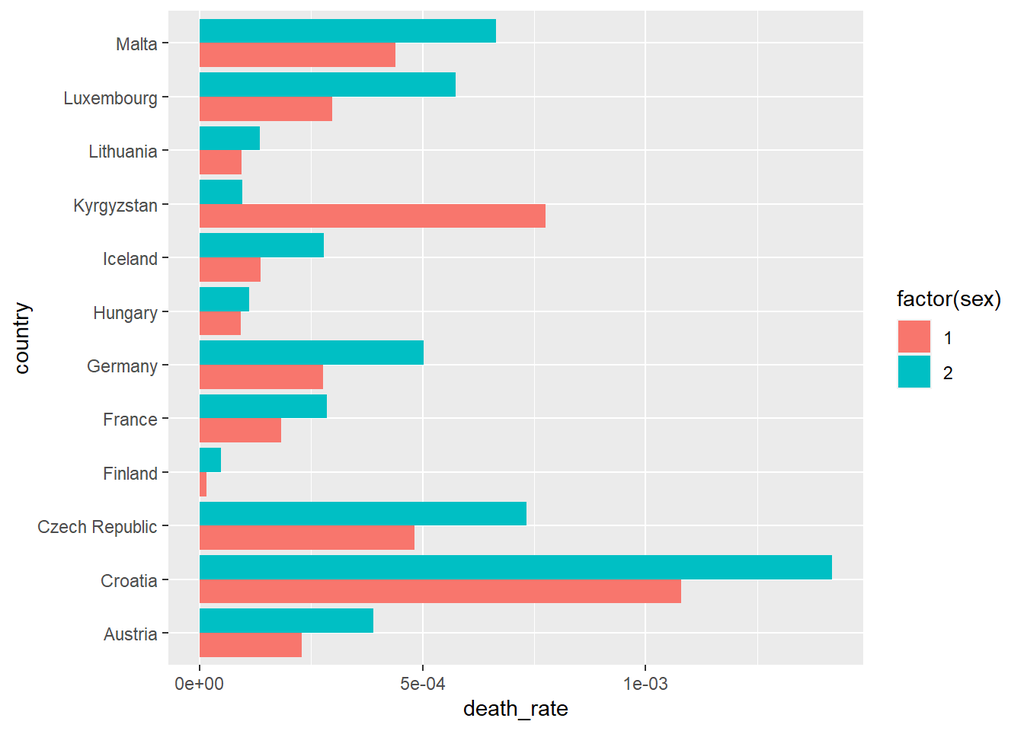

```r
stroke %>%
    ggplot()+
    geom_col(
        mapping = aes(y = country, x = death_rate, fill = factor(sex)),
        position = "dodge"
    )
```

# Conclussion

Except in Kyrgyzstan where crude death rate for cause I64 (Stroke not specified whether ischaemic or haemorrhagic) is higher in sex 1 compared to sex 2, the crude death rate for cause I64 (Stroke not specified whether ischaemic or haemorrhagic) is generally higher in sex 2 compared to sex 1 for all other countries.